# Public Trust: For Whom and For What?

Week 3 Wednesday — Chapter 3

NRES 315: Human Dimensions of Fish and Wildlife Management

2026-08-28

## Today’s question

What does it mean to manage fish and wildlife as a public trust?

Source: Chapter 3, §3.1–3.2.

## What you should be able to do

By the end of today, you should be able to:

- distinguish public trust thinking from the public trust doctrine;
- identify assets, beneficiaries, trustees, and trust managers in a management problem; and
- connect one historical legacy to a public-trust responsibility in a current decision.

Source: Chapter 3, §§3.1–3.4.

## A public responsibility

Fish and wildlife management asks not only what works, but for whom it must work.

## The public-trust starting point

Free-ranging fish and wildlife are generally treated as public resources rather than objects of private ownership.

Public trust thinking asks managers to steward these resources for current and future publics.

Source: Chapter 3, §3.2.

## An endowment, not a private commodity

Public trust thinking begins from three linked claims:

- fish and wildlife are an endowment held across generations;
- their benefits deserve fair consideration for all citizens; and
- government has a stewardship responsibility that cannot be reduced to serving one present-day user group.

Source: Chapter 3, §§3.2–3.3 and Table 3.1.

## Public trust is the responsibility; thinking is how we use it

**Public trust** is the public relationship: governments hold a responsibility to care for shared fish and wildlife resources on behalf of the public.

**Public-trust thinking** is the decision frame: use that responsibility to ask what is being held in trust, who is affected, who has authority, what future options matter, and how decision-makers will be accountable.

Public trust names the relationship. Public-trust thinking turns that relationship into questions for a real decision.

Source: Chapter 3, §§3.1–3.3.

## Core public-trust questions

- What are the trust assets?
- Who are the beneficiaries?
- Who acts as trustee, trust manager, or trust administrator?
- How are current and future generations considered?
- How can beneficiaries hold administrators accountable?

Source: Chapter 3, §3.1–3.3.

## A trust has connected roles

**Assets:** Fish and wildlife within a government’s jurisdiction.

**Beneficiaries:** Current and future publics with legitimate interests in how those assets are managed.

**Trustees:** Public officials with authority to make or direct public decisions.

**Trust managers:** Professional staff who develop options, implement decisions, communicate, and learn from results.

The public-trust question is relational: who is responsible to whom, for what, and across what time horizon?

Source: Chapter 3, §§3.3.1–3.3.3.

## Trustees and trust managers do different work

**Trustees**

Public officials who set direction, make decisions, and are accountable to beneficiaries.

**Trust managers**

Professional staff who develop options, implement decisions, communicate, and learn from results.

Authority and expertise are connected, but they are not interchangeable.

Source: Chapter 3, §3.3.3.

## Intergenerational equity

Present generations have responsibilities to steward resources so that current choices do not foreclose important future options.

Source: Chapter 3, §3.2.

## Intergenerational equity changes the time horizon

**A narrow present-only question**

Who gains or loses from this decision now?

**A public-trust question**

What options, resources, and responsibilities will this decision leave for future beneficiaries?

Source: Chapter 3, §3.2.

## Accountability is part of stewardship

Trust administrators need to explain what information they considered, how public input was used, and why a decision was made.

Transparency does not guarantee agreement.

It gives beneficiaries a basis to understand and evaluate whether administrators are serving the public interest.

Source: Chapter 3, §3.4.

## Public trust thinking and doctrine

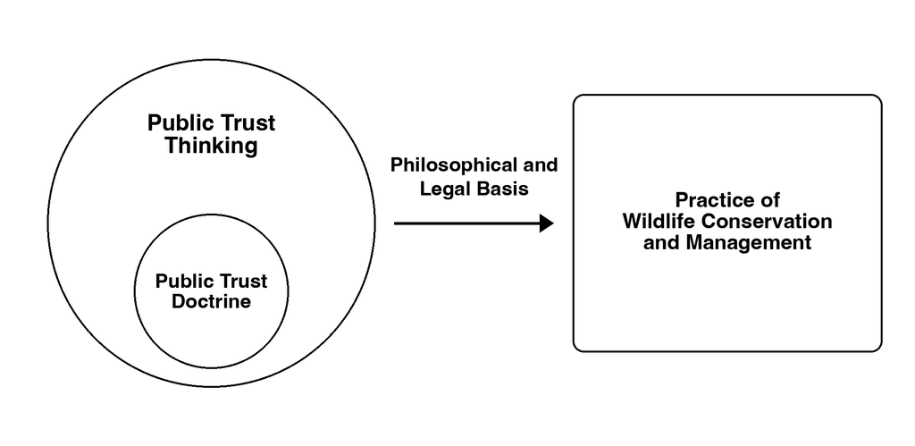

Public trust thinking guides law, policy, and practice; the doctrine is one legal expression of that responsibility.

Source: Chapter 3, §3.2–3.3.

## Doctrine is one tool within a broader responsibility

**Public trust** establishes the public responsibility for the resource.

**Public trust thinking** is the broader philosophical and practical orientation that applies that responsibility to stewardship choices.

**Public trust doctrine** is a legal concept that can define or protect public interests in particular settings.

Legal compliance matters, but it does not exhaust the question of whether a decision serves current and future beneficiaries well.

Source: Chapter 3, §§3.3.4–3.4.

## From framework to decision

Public-trust thinking becomes useful when a public institution must make a specific choice under uncertainty.

On Friday, use the framework to advise an agency considering a temporary harvest restriction after a documented population decline.

## Friday application: public-trust stewardship decision

**The decision your group will advise:** A state fish and wildlife agency has documented a population decline and is considering a **temporary harvest restriction before the next season**.

The agency must decide whether and how to act, explain its rationale to affected publics, and state what would trigger a review or revision.

Use Chapter 3 and your in-class reasoning only. Do not add outside legal claims, biological estimates, or case facts.

Source: Chapter 3, §§3.2–3.4.

## What Friday will look like

1. **0–5 minutes — Start alone:** Identify the decision, one beneficiary, and one question the agency should answer.
2. **5–8 minutes — Form your group:** Record names and preassigned roles.
3. **8–30 minutes — Build the recommendation:** Complete all four response sections with the Chapter 3 framework.
4. **30–34 minutes — Submit:** One present member submits the shared Canvas response.
5. **34–44 minutes — Defend the reasoning:** Be ready to explain the part connected to your role.
6. **44–50 minutes — Individual check and close:** Complete the private Friday Group Check, then synthesize the decision.

## What your group will submit

Submit one shared Canvas response with the names and roles of everyone present. Write 2–3 concise, complete sentences under each heading:

1. **Public responsibility and decision:** State the decision and explain why it is a public-trust responsibility rather than only one current user group’s preference.
2. **Beneficiaries across time:** Identify at least two current beneficiaries and one future beneficiary. Explain how their interests may differ.
3. **Tradeoff and trustee responsibility:** Explain one genuine consequence of a temporary restriction and how an accountable trustee should weigh it against protecting future options.
4. **Transparent accountability plan:** Recommend one specific way the agency should explain or review its decision. State what evidence, condition, or question should prompt reconsideration.

Aim for about 200–350 words total. The shared response is 80% of the score; the individual Group Check is 20%.

## Close: what your Friday response must show

Your group is **not** predicting the correct harvest rule or representing only one current user group.

Your group is advising an accountable public trustee:

> Given a documented population decline, should the agency use a temporary harvest restriction before the next season, and how should it make and review that decision for a broad public across time?

A strong response makes visible:

- a specific decision and its public responsibility;
- current and future beneficiaries whose interests may differ;
- a genuine tradeoff and trustee reasoning; and
- a transparent explanation or review plan with a trigger for reconsideration.

Source: Chapter 3, §§3.2–3.4.